# Анализ данных pollutio

# Загрука данных

```r
df <- read.csv("../stat2021_sm/POLLUTIO.STD/POLLUTIO.txt", sep = "\t", dec = ",")
df |> head(5)
```

```
##   PREC JANT JULT OVR65 POPN EDUC HOUS DENS NONW WWDRK POOR HC NOX SO2 HUMID
## 1   36   27   71   8.1 3.34 11.4 81.5 3243  8.8  42.6 11.7 21  15  59    59
## 2   35   23   72  11.1 3.14 11.0 78.8 4281  3.5  50.7 14.4  8  10  39    57
## 3   44   29   74  10.4 3.21  9.8 81.6 4260  0.8  39.4 12.4  6   6  33    54
## 4   47   45   79   6.5 3.41 11.1 77.5 3125 27.1  50.2 20.6 18   8  24    56
## 5   43   35   77   7.6 3.44  9.6 84.6 6441 24.4  43.7 14.3 43  38 206    55
##       MORT
## 1  921.870
## 2  997.875
## 3  962.354
## 4  982.291
## 5 1071.289
```

16 признаков, 60 наблюдений.

## Описание признаков:

1. *PREC* - Среднегодовое количество осадков в дюймах - количественный, дискретный (5 значений равны моде)
2. *JANT* - Средняя температура января в градусах по фаренгейту - количественный дискретный (5 значений равны моде)
3. *JULT* - То же для Июля - количественный дискретный (11 значений равны моде)
4. *OVR65* - Процент населения на 1960 г. в возрасте 65 лет и старше - количественный непрерывный
5. *POPN* - Средний размер домохозяйства (среднее количество людей на домохозяйство) - количественный непрерывный
6. *EDUC* - Средняя продолжительность обучения в школе для лиц старше 22 лет в годах - количественный непрерывный
7. *HOUS* - Процент жилья, отвечающего требованиям безопасности и имеющего все удобства - количественный непрерывный
8. *DENS* - Численность населения на квадратную милю в урбанизированных районах на 1960 г. - количественный непрерывный
9. *NONW* - Процент небелого населения в урбанизированных районах на 1960 г. - количественный непрерывный
10. *WWDRK* - Процент людей занятых в профессиях “белых воротничков” - количественный непрерывный
11. *POOR* - Процент семей с доходом меньше $3000 - количественный непрерывный
12. *HC* - Относительный потенциал загрязнения углеводородами - количественный дискретный (5 значений равны моде)
13. *NOX* - То же для оксидов азота - количественный дискретный (7 значений равны моде)
14. *SO2* - То же для диоксида серы - количественный дискретный (6 значений равны моде)
15. *HUMID* - Среднегодовая относительная влажность воздуха в 1PM в процентах - количественный дискретный (11 значений равны моде)
16. *MORT* - Общий показатель смертности с поправкой на возраст на 100 000 человек - количественный непрерывный

## Matrix-Scatterplot

```r
df |>
  scatterPlotMatrix(corrPlotType = "Text",
                    plotProperties = list(noCatColor = "Indigo"),
                    slidersPosition = list(dimCount = 6, xStartingDimIndex = 1, yStartingDimIndex = 1),
                    controlWidgets = TRUE, height = 1050, width = 1000)
```

[interactive chart not shown]

## Статистическая сводка

```r
describe(df, type = 1, check = FALSE, range = FALSE) |>
  as.data.frame() |>
  mutate(vars = NULL)
```

```
##        n        mean           sd        skew    kurtosis          se
## PREC  60   37.366667    9.9846775 -0.78198576  1.08074962   1.2890163
## JANT  60   33.983333   10.1688985  0.93652493  0.90089956   1.3127992
## JULT  60   74.583333    4.7631768  0.13326411 -0.08830705   0.6149235
## OVR65 60    8.798333    1.4645520 -0.03325710 -0.65287903   0.1890728
## POPN  60    3.263167    0.1352523 -0.47699736 -0.05808509   0.0174610
## EDUC  60   10.973333    0.8452994 -0.21926584 -0.78851744   0.1091277
## HOUS  60   80.913333    5.1413731 -0.40650405  0.25522120   0.6637484
## DENS  60 3876.050000 1454.1023607  1.34476326  3.20028428 187.7238076
## NONW  60   11.870000    8.9211480  1.10265145  0.76142433   1.1517153
## WWDRK 60   46.081667    4.6130431  0.09597673  0.41131932   0.5955413
## POOR  60   14.373333    4.1600956  1.42667894  1.30841132   0.5370660
## HC    60   37.850000   91.9776732  5.45260424 31.76307899  11.8742666
## NOX   60   22.650000   46.3332896  5.03550880 27.70155173   5.9816020
## SO2   60   53.766667   63.3904678  1.86366710  3.16409616   8.1836742
## HUMID 60   57.666667    5.3699309  0.23152878  3.84192311   0.6932551
## MORT  60  940.358433   62.2062785  0.09594159  0.05166494   8.0307960
```

## Переход к логарифму

Логарифмируемые переменные:

1. *DENS*
2. *NONW*
3. *POOR*
4. *HC*
5. *NOX*
6. *SO2*

```r
df.log <- df |> mutate(DENS = log(DENS), NONW = log(NONW), POOR = log(POOR), HC = log(HC), NOX = log(NOX), SO2 = log(SO2))
df.log |>
  scatterPlotMatrix(corrPlotType = "Text",
                    plotProperties = list(noCatColor = "Indigo"),
                    slidersPosition = list(dimCount = 6, xStartingDimIndex = 1, yStartingDimIndex = 1),
                    controlWidgets = TRUE, height = 1050, width = 1000)
```

[interactive chart not shown]

## Статистическая сводка для логарифмированных данных

```r
describe(df.log, type = 1, check = FALSE, range = FALSE) |>
  as.data.frame() |>
  mutate(vars = NULL)
```

```
##        n       mean         sd        skew    kurtosis         se
## PREC  60  37.366667  9.9846775 -0.78198576  1.08074962 1.28901633
## JANT  60  33.983333 10.1688985  0.93652493  0.90089956 1.31279915
## JULT  60  74.583333  4.7631768  0.13326411 -0.08830705 0.61492348
## OVR65 60   8.798333  1.4645520 -0.03325710 -0.65287903 0.18907284
## POPN  60   3.263167  0.1352523 -0.47699736 -0.05808509 0.01746100
## EDUC  60  10.973333  0.8452994 -0.21926584 -0.78851744 0.10912768
## HOUS  60  80.913333  5.1413731 -0.40650405  0.25522120 0.66374842
## DENS  60   8.198521  0.3617896 -0.08492857  0.47280550 0.04670684
## NONW  60   2.159632  0.8677874 -0.53677219 -0.10219483 0.11203087
## WWDRK 60  46.081667  4.6130431  0.09597673  0.41131932 0.59554130
## POOR  60   2.630503  0.2565516  0.91122823  0.26343036 0.03312066
## HC    60   2.753290  1.1758532  0.51929892  1.25816880 0.15180200
## NOX   60   2.323627  1.1844134  0.36247036  0.27106390 0.15290711
## SO2   60   3.197213  1.4976081 -0.69650222 -0.08329158 0.19334037
## HUMID 60  57.666667  5.3699309  0.23152878  3.84192311 0.69325510
## MORT  60 940.358433 62.2062785  0.09594159  0.05166494 8.03079602
```

Видно, что гистограммы прологарифмированных признаков стали чуть больше похожи на плотность нормального распределения, и их коэффициенты асимметрии и эксцесса стали ближе к 0.

## Выявление и удаление выбросов

На графиках зависимостей параметров загрязнения (*HC, NOX, SO2*) и влажности (*HUMID*) можно увидеть отклонения от закономерностей. Например на графике зависимости *SO2* от *NOX* выделяются точки справа от “облака” и под ним, которые портят линейную зависимость этих признаков, а на графике *HUMID* от *NOX* выделяются точки над и под “облаком”.

Чтобы объяснить неоднородность выборки относительно зависимости *SO2* от *NOX*, добавим к данным новую переменную - разницу между июльской и январской температурами и покрасим точки в зависимости от значения этого признака.

```r
df.log <- df.log |> mutate(TDIFF = JULT - JANT)
df.log |>
  scatterPlotMatrix(corrPlotType = "Text",
                    plotProperties = list(noCatColor = "Indigo"),
                    slidersPosition = list(dimCount = 6, xStartingDimIndex = 1, yStartingDimIndex = 1),
                    zAxisDim = "TDIFF",
                    controlWidgets = TRUE, height = 1050, width = 1000)
```

[interactive chart not shown]

Видно, что эта неоднородность объясняется новым признаком разброса температур.

Точки, в которых логарифм *SO2* равен 0, было решено оставить, так как этих точек много, и они являются выбросами только относительно признака *SO2*, который, возможно, будет убран из дальнейшего анализа (за счёт сильной корреляции с другими параметрами загрязнения).

Также за выброс можно считать точку с максимальной январской температурой (*JANT*), так как на графиках зависимости этого признака от признаков *OVR65* и *POPN* эта точка не выглядит как часть закономерности. Однако, из-за сильной корреляции признаков *JULT* и *JANT* последний, возможно, будет убран из будущего анализа, а эта точка подчиняется остальным закономерностям, поэтому её тоже решено было оставить.

### Графики после удаления выбросов:

```r
pollution.outliers <- c(21, 29, 47, 48, 49)
humidity.outliers <- c(18, 29, 41, 48, 49, 50)
so2.zero.outliers <- c(25, 32, 37, 56)
jant.outliers <- c(32)

outliers <- union(pollution.outliers, humidity.outliers)
df.clean <- df.log[-outliers,]
df.clean |>
  scatterPlotMatrix(corrPlotType = "Text",
                    plotProperties = list(noCatColor = "Indigo"),
                    slidersPosition = list(dimCount = 6, xStartingDimIndex = 1, yStartingDimIndex = 1),
                    controlWidgets = TRUE, height = 1050, width = 1000)
```

[interactive chart not shown]

## Статистическая сводка после удаления выбросов:

```r
describe(df.clean, type = 1, check = FALSE, range = FALSE) |>
  as.data.frame() |>
  mutate(vars = NULL)
```

```
##        n       mean         sd        skew      kurtosis         se
## PREC  52  39.846154  7.1438569  0.34340251  0.0934201216 0.99067470
## JANT  52  32.326923  9.4385965  1.33209204  2.7629220402 1.30889783
## JULT  52  75.326923  3.9293823  0.58117799 -0.5516794427 0.54490728
## OVR65 52   8.823077  1.4766968 -0.11013246 -0.6138462005 0.20478100
## POPN  52   3.289038  0.1146907 -0.29192462  0.1652700943 0.01590474
## EDUC  52  10.807692  0.7788494 -0.14843241 -0.5766448360 0.10800697
## HOUS  52  80.153846  4.8838052 -0.53470249  0.2993919102 0.67726193
## DENS  52   8.208786  0.3694151 -0.05806684  0.4577706502 0.05122865
## NONW  52   2.211952  0.9008831 -0.67458922 -0.0325850757 0.12493001
## WWDRK 52  45.309615  4.4140711  0.32694951  1.2465326901 0.61212152
## POOR  52   2.645191  0.2625463  0.88092745  0.0888317603 0.03640862
## HC    52   2.567416  0.8770176 -0.16131776  0.0932622695 0.12162046
## NOX   52   2.188182  1.0011750 -0.05431763 -0.6179810414 0.13883800
## SO2   52   3.236624  1.4872371 -0.69290286 -0.0005023825 0.20624268
## HUMID 52  57.192308  2.6571285  0.22151733 -0.5356379161 0.36847742
## MORT  52 951.169250 58.0422699  0.12122238  0.1714120354 8.04901462
## TDIFF 52  43.000000  6.7330033 -1.48751673  5.2935489278 0.93369956
```

# Удаление признаков

```r
df.new <- df.clean |> select(-HC, -SO2, -JANT, -JULT, -TDIFF, -WWDRK, -HUMID)
df.new |> colnames() |> print()
```

```
##  [1] "PREC"  "OVR65" "POPN"  "EDUC"  "HOUS"  "DENS"  "NONW"  "POOR"  "NOX"
## [10] "MORT"
```

# Описание распределений признаков

Добавим новый категориальный признак, разделяющий выборку на группы по количеству осадков (больше/меньше медианы)

```r
df.new <- df.new |> mutate(CLIM = factor(ifelse(PREC > median(PREC), ">.5", "<.5"), levels = c("<.5", ">.5")))
```

1. *NOX*
2. *POPN*
3. *POOR*
4. *OVR65*
5. *HOUS*
6. *EDUC*
7. *MORT*

# Регрессионный анализ

### Scatterplot для всех признаков

```r
df.new <- df.log |> select(-HC, -SO2, -JANT, -JULT, -TDIFF, -WWDRK, -HUMID) |>
        mutate(CLIMTemper = ifelse(PREC > median(PREC), 1, 0))
df.new |>
  # select(-CLIM) |>
  scatterPlotMatrix(corrPlotType = "Text",
                    regressionType = 1,
                    plotProperties = list(noCatColor = "Indigo"),
                    slidersPosition = list(dimCount = 10, xStartingDimIndex = 1, yStartingDimIndex = 1),
                    categoricalCS = "Set1",
                    controlWidgets = TRUE, height = 1050, width = 1000)
```

[interactive chart not shown]

### Зависимый признак: *MORT*

### Регрессоры: все остальные признаки

```r
linear.model <- lm(MORT ~ ., data = df.new)
summary(linear.model)
```

```
##
## Call:
## lm(formula = MORT ~ ., data = df.new)
##
## Residuals:
##      Min       1Q   Median       3Q      Max
## -103.316  -20.506    0.305   21.749   76.937
##
## Coefficients:
##             Estimate Std. Error t value Pr(>|t|)
## (Intercept) 963.5435   430.2644   2.239 0.029700 *
## PREC          3.4480     1.1066   3.116 0.003064 **
## OVR65        -0.8885     7.3269  -0.121 0.903975
## POPN         21.8203    60.1077   0.363 0.718151
## EDUC        -14.6406     9.0730  -1.614 0.113028
## HOUS         -2.5240     1.5848  -1.593 0.117687
## DENS         19.8538    16.6074   1.195 0.237653
## NONW         23.6700    11.2502   2.104 0.040537 *
## POOR        -39.5997    33.0848  -1.197 0.237099
## NOX          20.8231     5.6235   3.703 0.000541 ***
## CLIMTemper  -17.8802    16.3916  -1.091 0.280689
## ---
## Signif. codes:  0 '***' 0.001 '**' 0.01 '*' 0.05 '.' 0.1 ' ' 1
##
## Residual standard error: 36.68 on 49 degrees of freedom
## Multiple R-squared:  0.7112, Adjusted R-squared:  0.6523
## F-statistic: 12.07 on 10 and 49 DF,  p-value: 3.657e-10
```

### Оценки стандартизованных признаков $\beta$

```r
linear.model.beta <- lm.beta(linear.model)
summary(linear.model.beta)
```

```
##
## Call:
## lm(formula = MORT ~ ., data = df.new)
##
## Residuals:
##      Min       1Q   Median       3Q      Max
## -103.316  -20.506    0.305   21.749   76.937
##
## Coefficients:
##              Estimate Standardized Std. Error t value Pr(>|t|)
## (Intercept) 963.54345           NA  430.26444   2.239 0.029700 *
## PREC          3.44803      0.55344    1.10662   3.116 0.003064 **
## OVR65        -0.88852     -0.02092    7.32693  -0.121 0.903975
## POPN         21.82030      0.04744   60.10768   0.363 0.718151
## EDUC        -14.64062     -0.19895    9.07304  -1.614 0.113028
## HOUS         -2.52396     -0.20861    1.58483  -1.593 0.117687
## DENS         19.85378      0.11547   16.60736   1.195 0.237653
## NONW         23.67000      0.33020   11.25022   2.104 0.040537 *
## POOR        -39.59968     -0.16332   33.08480  -1.197 0.237099
## NOX          20.82312      0.39647    5.62354   3.703 0.000541 ***
## CLIMTemper  -17.88020     -0.14485   16.39157  -1.091 0.280689
## ---
## Signif. codes:  0 '***' 0.001 '**' 0.01 '*' 0.05 '.' 0.1 ' ' 1
##
## Residual standard error: 36.68 on 49 degrees of freedom
## Multiple R-squared:  0.7112, Adjusted R-squared:  0.6523
## F-statistic: 12.07 on 10 and 49 DF,  p-value: 3.657e-10
```

### Модель, построенная по стандартизованным признакам

```r
df.scale <- df.new |>
  scale() |>
  as.data.frame()
linear.model.scale.all.beta <- lm.beta(lm(MORT ~ ., data = df.scale))
summary(linear.model.scale.all.beta)
```

```
##
## Call:
## lm(formula = MORT ~ ., data = df.scale)
##
## Residuals:
##     Min      1Q  Median      3Q     Max
## -1.6608 -0.3296  0.0049  0.3496  1.2368
##
## Coefficients:
##               Estimate Standardized Std. Error t value Pr(>|t|)
## (Intercept)  5.061e-16           NA  7.612e-02   0.000 1.000000
## PREC         5.534e-01    5.534e-01  1.776e-01   3.116 0.003064 **
## OVR65       -2.092e-02   -2.092e-02  1.725e-01  -0.121 0.903975
## POPN         4.744e-02    4.744e-02  1.307e-01   0.363 0.718151
## EDUC        -1.989e-01   -1.989e-01  1.233e-01  -1.614 0.113028
## HOUS        -2.086e-01   -2.086e-01  1.310e-01  -1.593 0.117687
## DENS         1.155e-01    1.155e-01  9.659e-02   1.195 0.237653
## NONW         3.302e-01    3.302e-01  1.569e-01   2.104 0.040537 *
## POOR        -1.633e-01   -1.633e-01  1.364e-01  -1.197 0.237099
## NOX          3.965e-01    3.965e-01  1.071e-01   3.703 0.000541 ***
## CLIMTemper  -1.448e-01   -1.448e-01  1.328e-01  -1.091 0.280689
## ---
## Signif. codes:  0 '***' 0.001 '**' 0.01 '*' 0.05 '.' 0.1 ' ' 1
##
## Residual standard error: 0.5897 on 49 degrees of freedom
## Multiple R-squared:  0.7112, Adjusted R-squared:  0.6523
## F-statistic: 12.07 on 10 and 49 DF,  p-value: 3.657e-10
```

Подтвердили, что $\beta$ действительно считаются как оценки регрессии по стандартизованным признакам, а также посчитали стандартные отклонения от них

### Корреляции стандартизованных оценок коэффициентов регрессии

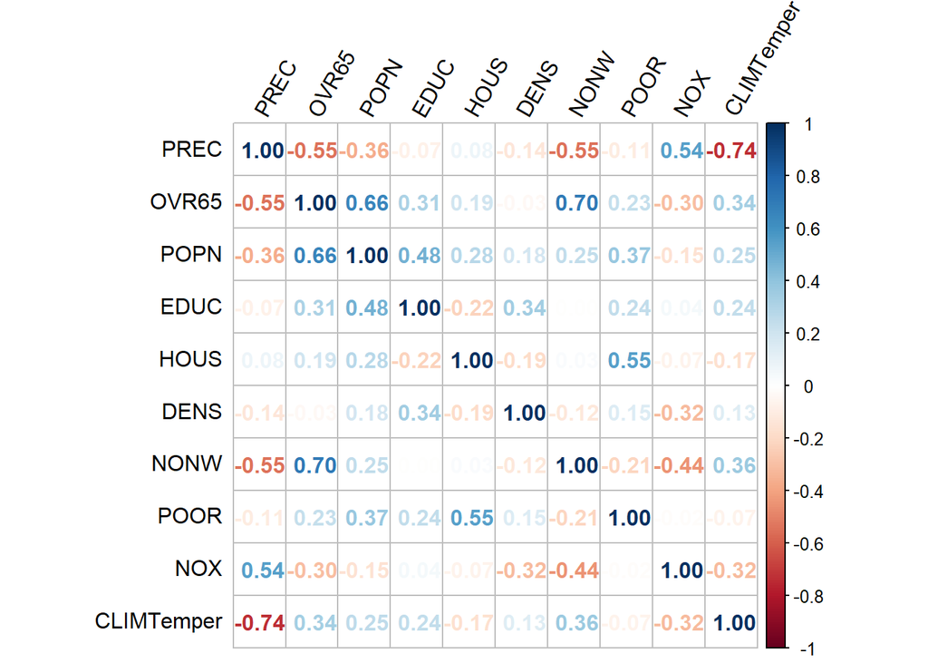

```r
resid.scale.all <- linear.model.scale.all.beta$residuals
sigma2.scale.all <- sum(resid.scale.all^2) / (nrow(df.scale) - ncol(df.scale))
cov.beta.all <- df.scale |> select(-MORT) |> cor() |> solve() * sigma2.scale.all / nrow(df.scale)
cov.beta.all |>
  cov2cor() |>
  corrplot(method = "number", tl.col = "black", tl.srt = 60)
```

Есть несколько сильно коррелирующих признаков.

### Вырожденность признака и частные корреляции

```r
cbind(ols_vif_tol(linear.model.scale.all.beta), ols_correlations(linear.model.scale.all.beta)) |>
  as.data.frame() |>
  select(Variables, Tolerance, Partial, VIF)
```

```
##             Variables Tolerance     Partial      VIF
## PREC             PREC 0.1867890  0.40665203 5.353634
## OVR65           OVR65 0.1980439 -0.01732131 5.049386
## POPN             POPN 0.3450373  0.05179043 2.898238
## EDUC             EDUC 0.3876938 -0.22462898 2.579355
## HOUS             HOUS 0.3434735 -0.22184189 2.911433
## DENS             DENS 0.6316869  0.16834555 1.583063
## NONW             NONW 0.2392581  0.28784475 4.179587
## POOR             POOR 0.3165258 -0.16854173 3.159300
## NOX               NOX 0.5140315  0.46758875 1.945406
## CLIMTemper CLIMTemper 0.3342090 -0.15397271 2.992140
```

Хорошо приближаются линейно через другие признаки *PREC*, *OVR65*, *NONW*, *POOR* и *CLIM*.

Из них кандидаты на удаление: - *CLIM*, так как сильно коррелирует с *PREC* и имеет достаточно малую частную корреляцию с предсказываемым признаком. - *OVR65*, так как коррелирует с *NONW* и имеет малую частную корреляцию.

### Модель без *OVR65*, *CLIMTemper*

```r
linear.model.scale <- lm(MORT ~ . - OVR65 - CLIMTemper, data = df.scale)
summary(linear.model.scale)
```

```
##
## Call:
## lm(formula = MORT ~ . - OVR65 - CLIMTemper, data = df.scale)
##
## Residuals:
##      Min       1Q   Median       3Q      Max
## -1.70691 -0.34788  0.02142  0.26269  1.34493
##
## Coefficients:
##               Estimate Std. Error t value Pr(>|t|)
## (Intercept)  5.539e-16  7.557e-02   0.000 1.000000
## PREC         4.256e-01  1.055e-01   4.035 0.000183 ***
## POPN         6.241e-02  9.742e-02   0.641 0.524649
## EDUC        -1.744e-01  1.149e-01  -1.518 0.135210
## HOUS        -2.414e-01  1.236e-01  -1.953 0.056312 .
## DENS         1.314e-01  9.474e-02   1.387 0.171563
## NONW         3.664e-01  1.087e-01   3.371 0.001435 **
## POOR        -1.833e-01  1.300e-01  -1.410 0.164514
## NOX          3.654e-01  9.842e-02   3.713 0.000508 ***
## ---
## Signif. codes:  0 '***' 0.001 '**' 0.01 '*' 0.05 '.' 0.1 ' ' 1
##
## Residual standard error: 0.5854 on 51 degrees of freedom
## Multiple R-squared:  0.7038, Adjusted R-squared:  0.6574
## F-statistic: 15.15 on 8 and 51 DF,  p-value: 4.241e-11
```

```r
cbind(ols_vif_tol(linear.model.scale), ols_correlations(linear.model.scale)) |>
  as.data.frame() |>
  select(Variables, Tolerance, Partial, VIF)
```

```
##      Variables Tolerance     Partial      VIF
## PREC      PREC 0.5222334  0.49196191 1.914853
## POPN      POPN 0.6118915  0.08934353 1.634277
## EDUC      EDUC 0.4400623 -0.20790653 2.272406
## HOUS      HOUS 0.3802786 -0.26379342 2.629651
## DENS      DENS 0.6470172  0.19061722 1.545554
## NONW      NONW 0.4914534  0.42685866 2.034781
## POOR      POOR 0.3438622 -0.19374315 2.908142
## NOX        NOX 0.5995564  0.46128188 1.667900
```

Новые кандидаты на удаление за счёт малых частных корреляций: - *POPN* - *DENS* - *POOR*

Также удалили признак *HOUS* так как он не значим в модели.

Модель после удаления:

```r
lm.fin <- lm(MORT ~ PREC + EDUC + NONW + NOX, data = df.scale)
cbind(ols_vif_tol(lm.fin), ols_correlations(lm.fin)) |>
  as.data.frame() |>
  select(Variables, Tolerance, Partial)
```

```
##      Variables Tolerance    Partial
## PREC      PREC 0.5483201  0.4814262
## EDUC      EDUC 0.7185133 -0.3779811
## NONW      NONW 0.8286040  0.4781474
## NOX        NOX 0.7336229  0.4957752
```

```r
summary(lm.fin)
```

```
##
## Call:
## lm(formula = MORT ~ PREC + EDUC + NONW + NOX, data = df.scale)
##
## Residuals:
##      Min       1Q   Median       3Q      Max
## -1.71648 -0.33045 -0.00724  0.35465  1.40372
##
## Coefficients:
##               Estimate Std. Error t value Pr(>|t|)
## (Intercept)  3.433e-16  7.738e-02   0.000 1.000000
## PREC         4.293e-01  1.054e-01   4.073 0.000150 ***
## EDUC        -2.787e-01  9.206e-02  -3.028 0.003745 **
## NONW         3.461e-01  8.573e-02   4.037 0.000169 ***
## NOX          3.857e-01  9.111e-02   4.234  8.8e-05 ***
## ---
## Signif. codes:  0 '***' 0.001 '**' 0.01 '*' 0.05 '.' 0.1 ' ' 1
##
## Residual standard error: 0.5994 on 55 degrees of freedom
## Multiple R-squared:  0.6651, Adjusted R-squared:  0.6407
## F-statistic:  27.3 on 4 and 55 DF,  p-value: 1.666e-12
```

## Доверительные эллипсоиды

Посмотрим на корреляции между (стандартизованными) коэффициентами для оставшихся признаков

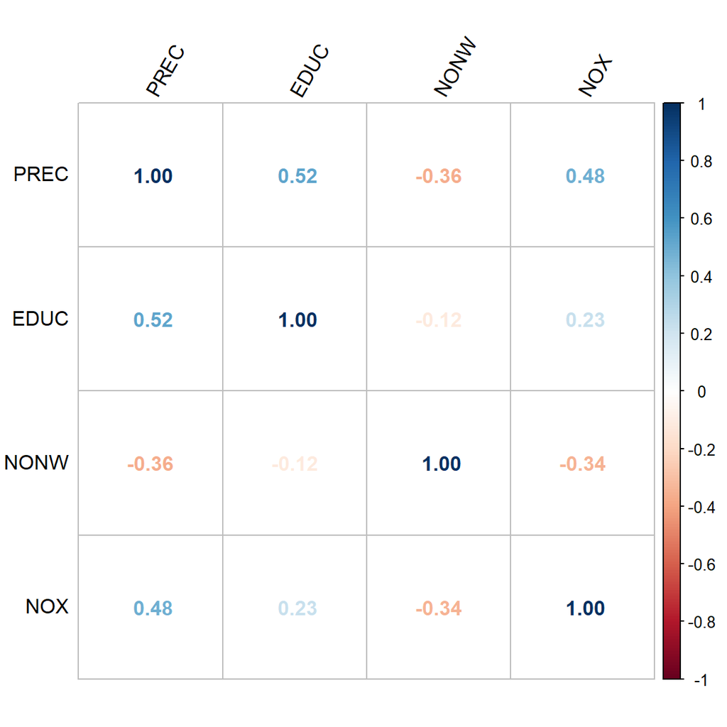

```r
resid <- lm.fin$residuals
sigma2 <- sum(resid^2) / (nrow(df.scale) - lm.fin$rank)
cov.beta <- lm.fin$model |> select(-MORT) |> cor() |> solve() * sigma2 / nrow(df.scale)
cov.beta |>
  cov2cor() |>
  corrplot(method = "number", tl.col = "black", tl.srt = 60)
```

Самая большая по модулю корреляция между признаками *PREC* и *EDUC*. Посмотрим на доверительный эллипс для стандартизованных коэффициентов этих признаков

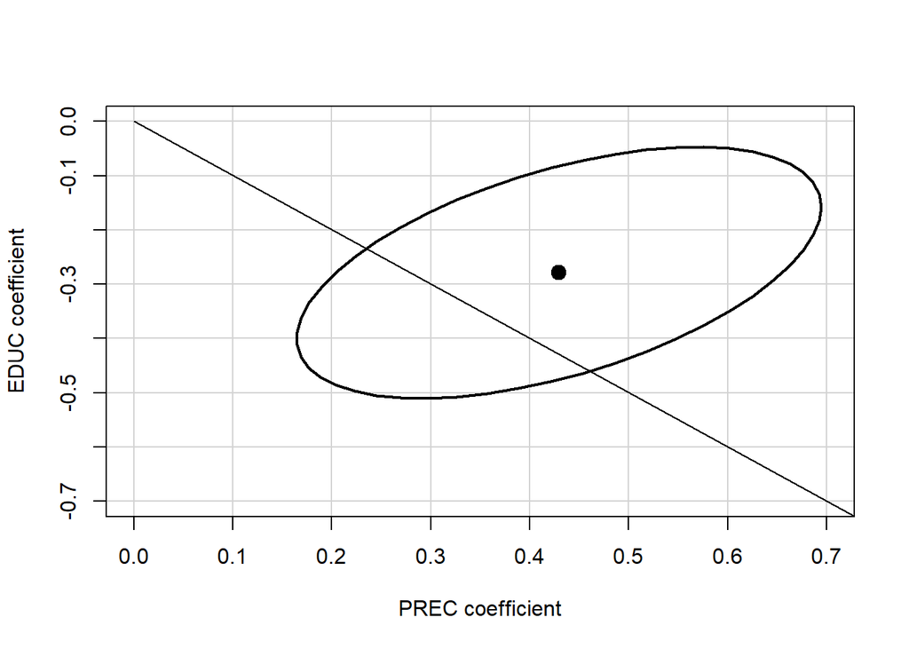

```r
confidenceEllipse(lm.fin, which.coef = c("PREC", "EDUC"), levels = 0.95, col = "black", xlim = c(0, 0.7), ylim = c(-0.7, 0))
lines(c(0, 0.8), c(0, -0.8))
```

Хорошая ситуация: признаки не являются супрессорами и нельзя сказать какой из них влияет на модель больше.

## Пошаговая регрессия

### Backward

```r
ols_step_backward_p(lm(MORT ~ ., data = df.scale))
```

```
##
##
##                              Stepwise Summary
## -------------------------------------------------------------------------
## Step    Variable        AIC        SBC       SBIC        R2       Adj. R2
## -------------------------------------------------------------------------
##  0      Full Model    118.735    143.868    -46.699    0.71124    0.65230
##  1      OVR65         116.753    139.791    -49.137    0.71115    0.65916
##  2      POPN          115.177    136.121    -51.309    0.70910    0.66347
## -------------------------------------------------------------------------
##
## Final Model Output
## ------------------
##
##                            Model Summary
## --------------------------------------------------------------------
## R                       0.842       RMSE                      0.535
## R-Squared               0.709       MSE                       0.337
## Adj. R-Squared          0.663       Coef. Var          3.794567e+17
## Pred R-Squared          0.510       AIC                     115.177
## MAE                     0.407       SBC                     136.121
## --------------------------------------------------------------------
##  RMSE: Root Mean Square Error
##  MSE: Mean Square Error
##  MAE: Mean Absolute Error
##  AIC: Akaike Information Criteria
##  SBC: Schwarz Bayesian Criteria
##
##                                ANOVA
## -------------------------------------------------------------------
##                Sum of
##               Squares        DF    Mean Square      F         Sig.
## -------------------------------------------------------------------
## Regression     41.837         8          5.230     15.54    0.0000
## Residual       17.163        51          0.337
## Total          59.000        59
## -------------------------------------------------------------------
##
##                                   Parameter Estimates
## ----------------------------------------------------------------------------------------
##       model      Beta    Std. Error    Std. Beta      t        Sig      lower     upper
## ----------------------------------------------------------------------------------------
## (Intercept)     0.000         0.075                  0.000    1.000    -0.150     0.150
##        PREC     0.542         0.146        0.542     3.703    0.001     0.248     0.835
##        EDUC    -0.220         0.107       -0.220    -2.065    0.044    -0.434    -0.006
##        HOUS    -0.221         0.124       -0.221    -1.783    0.081    -0.470     0.028
##        DENS     0.100         0.092        0.100     1.091    0.280    -0.084     0.284
##        NONW     0.371         0.100        0.371     3.710    0.001     0.170     0.571
##        POOR    -0.183         0.124       -0.183    -1.469    0.148    -0.433     0.067
##         NOX     0.389         0.100        0.389     3.878    0.000     0.187     0.590
##  CLIMTemper    -0.142         0.123       -0.142    -1.160    0.252    -0.389     0.104
## ----------------------------------------------------------------------------------------
```

```r
lm.backward <- ols_step_backward_p(lm(MORT ~ ., data = df.scale))
summary(lm.backward$model)
```

```
##
## Call:
## lm(formula = paste(response, "~", paste(c(include, cterms), collapse = " + ")),
##     data = l)
##
## Residuals:
##     Min      1Q  Median      3Q     Max
## -1.6436 -0.3347 -0.0053  0.3273  1.2079
##
## Coefficients:
##               Estimate Std. Error t value Pr(>|t|)
## (Intercept)  4.886e-16  7.489e-02   0.000 1.000000
## PREC         5.417e-01  1.463e-01   3.703 0.000524 ***
## EDUC        -2.203e-01  1.067e-01  -2.065 0.043977 *
## HOUS        -2.208e-01  1.239e-01  -1.783 0.080571 .
## DENS         9.989e-02  9.152e-02   1.091 0.280201
## NONW         3.706e-01  9.990e-02   3.710 0.000513 ***
## POOR        -1.829e-01  1.245e-01  -1.469 0.147925
## NOX          3.886e-01  1.002e-01   3.878 0.000303 ***
## CLIMTemper  -1.424e-01  1.228e-01  -1.160 0.251518
## ---
## Signif. codes:  0 '***' 0.001 '**' 0.01 '*' 0.05 '.' 0.1 ' ' 1
##
## Residual standard error: 0.5801 on 51 degrees of freedom
## Multiple R-squared:  0.7091, Adjusted R-squared:  0.6635
## F-statistic: 15.54 on 8 and 51 DF,  p-value: 2.736e-11
```

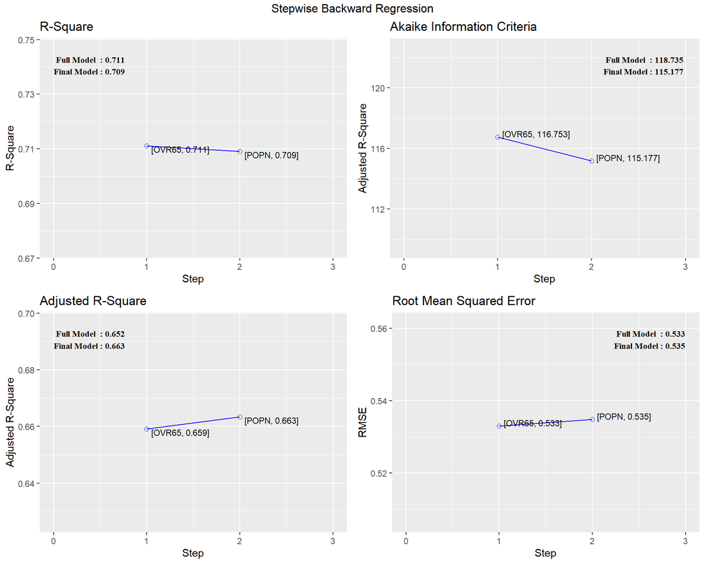

```r
plot(lm.backward)
```

### Forward

```r
ols_step_forward_p(lm(MORT ~ ., data = df.scale))
```

```
##
##
##                              Stepwise Summary
## -------------------------------------------------------------------------
## Step    Variable        AIC        SBC       SBIC        R2       Adj. R2
## -------------------------------------------------------------------------
##  0      Base Model    173.264    177.453      0.863    0.00000    0.00000
##  1      NONW          153.397    159.680    -19.321    0.30542    0.29344
##  2      EDUC          132.803    141.181    -39.151    0.52337    0.50665
##  3      NOX           129.455    139.926    -42.401    0.56402    0.54067
##  4      PREC          115.634    128.201    -54.087    0.66507    0.64071
##  5      CLIMTemper    114.105    128.765    -54.761    0.68420    0.65496
## -------------------------------------------------------------------------
##
## Final Model Output
## ------------------
##
##                            Model Summary
## --------------------------------------------------------------------
## R                       0.827       RMSE                      0.557
## R-Squared               0.684       MSE                       0.345
## Adj. R-Squared          0.655       Coef. Var          3.842225e+17
## Pred R-Squared          0.591       AIC                     114.105
## MAE                     0.439       SBC                     128.765
## --------------------------------------------------------------------
##  RMSE: Root Mean Square Error
##  MSE: Mean Square Error
##  MAE: Mean Absolute Error
##  AIC: Akaike Information Criteria
##  SBC: Schwarz Bayesian Criteria
##
##                                ANOVA
## -------------------------------------------------------------------
##                Sum of
##               Squares        DF    Mean Square      F         Sig.
## -------------------------------------------------------------------
## Regression     40.368         5          8.074    23.399    0.0000
## Residual       18.632        54          0.345
## Total          59.000        59
## -------------------------------------------------------------------
##
##                                   Parameter Estimates
## ----------------------------------------------------------------------------------------
##       model      Beta    Std. Error    Std. Beta      t        Sig      lower     upper
## ----------------------------------------------------------------------------------------
## (Intercept)     0.000         0.076                  0.000    1.000    -0.152     0.152
##        NONW     0.315         0.086        0.315     3.678    0.001     0.143     0.487
##        EDUC    -0.288         0.090       -0.288    -3.185    0.002    -0.469    -0.107
##         NOX     0.425         0.092        0.425     4.623    0.000     0.240     0.609
##        PREC     0.607         0.142        0.607     4.260    0.000     0.321     0.892
##  CLIMTemper    -0.215         0.119       -0.215    -1.809    0.076    -0.454     0.023
## ----------------------------------------------------------------------------------------
```

```r
lm.forward <- ols_step_forward_p(lm(MORT ~ ., data = df.scale))
summary(lm.forward$model)
```

```
##
## Call:
## lm(formula = paste(response, "~", paste(preds, collapse = " + ")),
##     data = l)
##
## Residuals:
##      Min       1Q   Median       3Q      Max
## -1.63802 -0.37438  0.00261  0.34131  1.20791
##
## Coefficients:
##               Estimate Std. Error t value Pr(>|t|)
## (Intercept)  3.237e-16  7.583e-02   0.000 1.000000
## NONW         3.153e-01  8.572e-02   3.678 0.000543 ***
## EDUC        -2.878e-01  9.036e-02  -3.185 0.002404 **
## NOX          4.246e-01  9.183e-02   4.623 2.39e-05 ***
## PREC         6.067e-01  1.424e-01   4.260 8.23e-05 ***
## CLIMTemper  -2.154e-01  1.191e-01  -1.809 0.076031 .
## ---
## Signif. codes:  0 '***' 0.001 '**' 0.01 '*' 0.05 '.' 0.1 ' ' 1
##
## Residual standard error: 0.5874 on 54 degrees of freedom
## Multiple R-squared:  0.6842, Adjusted R-squared:  0.655
## F-statistic:  23.4 on 5 and 54 DF,  p-value: 1.997e-12
```

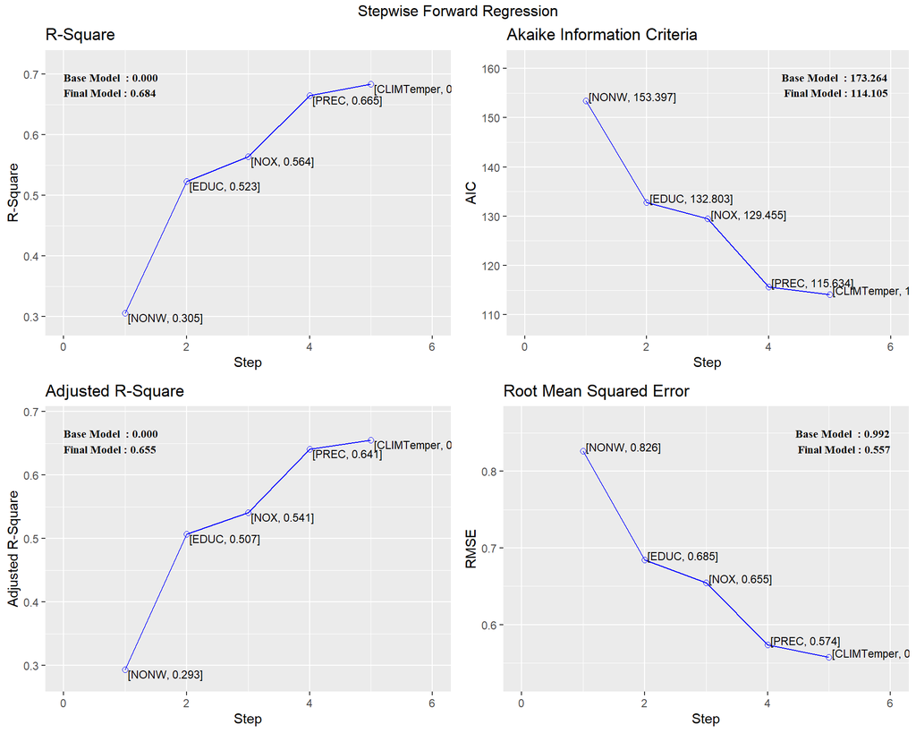

```r
plot(lm.forward)
```

В модели, полученной с помощью пошагового алгоритма Forward, осталось меньше признаков и меньший $R^2_{adj}$, чем в модели, полученной Backward.

### Метрики Backward, если брать все признаки

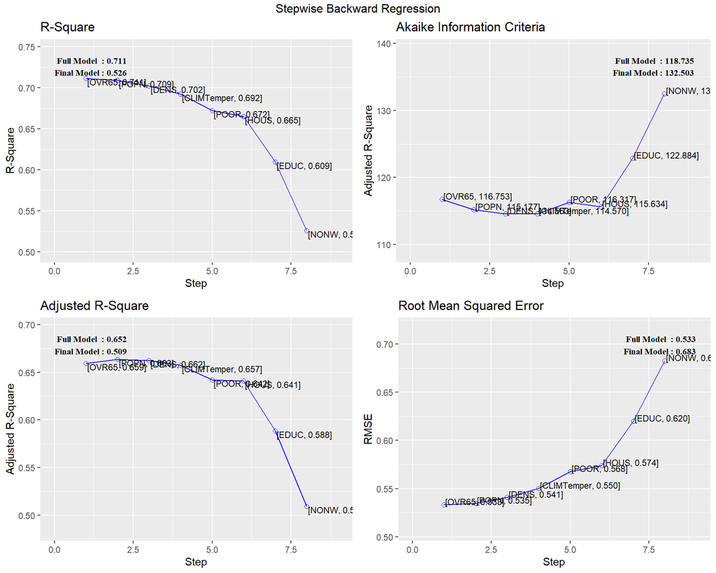

```r
plot(ols_step_backward_p(lm(MORT ~ ., data = df.scale), p_val = 1e-6))
```

## Финальная модель

Все коэффициенты в модели Forward, кроме *CLIM*, оказались значимы, а в Backward остались незначимые признаки, поэтому в итоге решено взять модель, полученную Forward, но без *CLIM*, так как он сильно коррелирует с *PREC* и является незначимым в модели при уровне значимости 0.05.

```r
df.dirty <- df.log |> select(-HC, -SO2, -JANT, -JULT, -TDIFF, -WWDRK, -HUMID) |>
        mutate(CLIMTemper = ifelse(PREC > median(PREC), 1, 0))
lm.fin.dirty <- lm.beta(lm(MORT ~ PREC + EDUC + NONW + NOX, data = df.dirty[-32,]))
summary(lm.fin.dirty)
```

```
##
## Call:
## lm(formula = MORT ~ PREC + EDUC + NONW + NOX, data = df.dirty[-32,
##     ])
##
## Residuals:
##     Min      1Q  Median      3Q     Max
## -105.06  -19.98   -1.54   19.84   86.91
##
## Coefficients:
##             Estimate Standardized Std. Error t value Pr(>|t|)
## (Intercept) 897.3420           NA    89.1422  10.066 5.41e-14 ***
## PREC          3.2291       0.5018     0.6440   5.014 6.09e-06 ***
## EDUC        -15.8147      -0.2172     6.5505  -2.414 0.019186 *
## NONW         25.1726       0.3553     5.7623   4.369 5.71e-05 ***
## NOX          18.6866       0.3487     4.5178   4.136 0.000124 ***
## ---
## Signif. codes:  0 '***' 0.001 '**' 0.01 '*' 0.05 '.' 0.1 ' ' 1
##
## Residual standard error: 34.95 on 54 degrees of freedom
## Multiple R-squared:  0.7028, Adjusted R-squared:  0.6807
## F-statistic: 31.92 on 4 and 54 DF,  p-value: 1.187e-13
```

## Адекватность модели

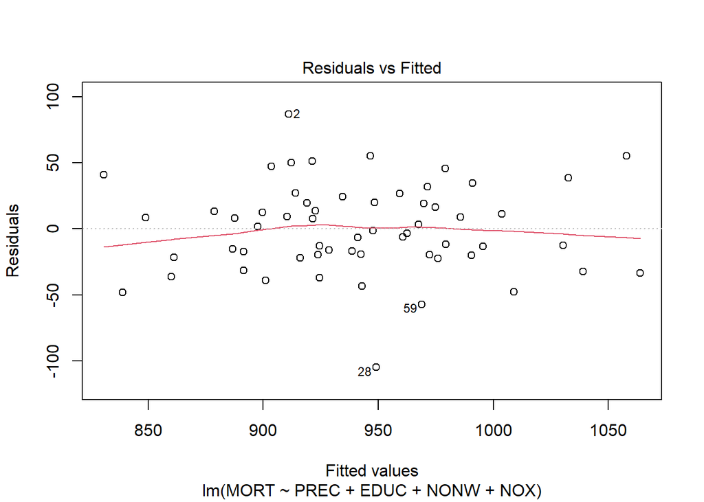

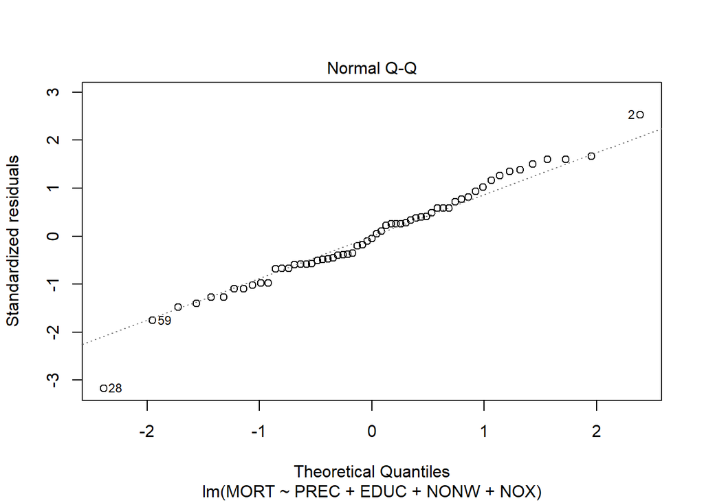

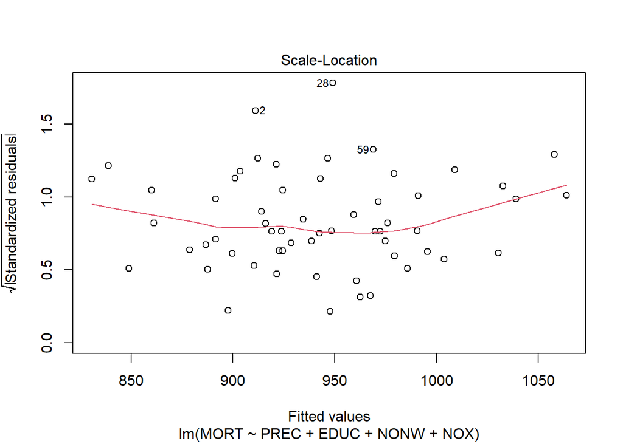

```r
plot(lm.fin.dirty, which = 1:3)
```

## Анализ выбросов

### Стьюдентизированные остатки vs стандартизованные остатки

График может показать выбросы, так как без выбросов стьюдентизированные остатки (deleted residuals поделённые на оценку их дисперсии) должны слабо отличаться от стандартизованных остатков в большую по модулю сторону. Красным проведена линия регрессии этих остатков.

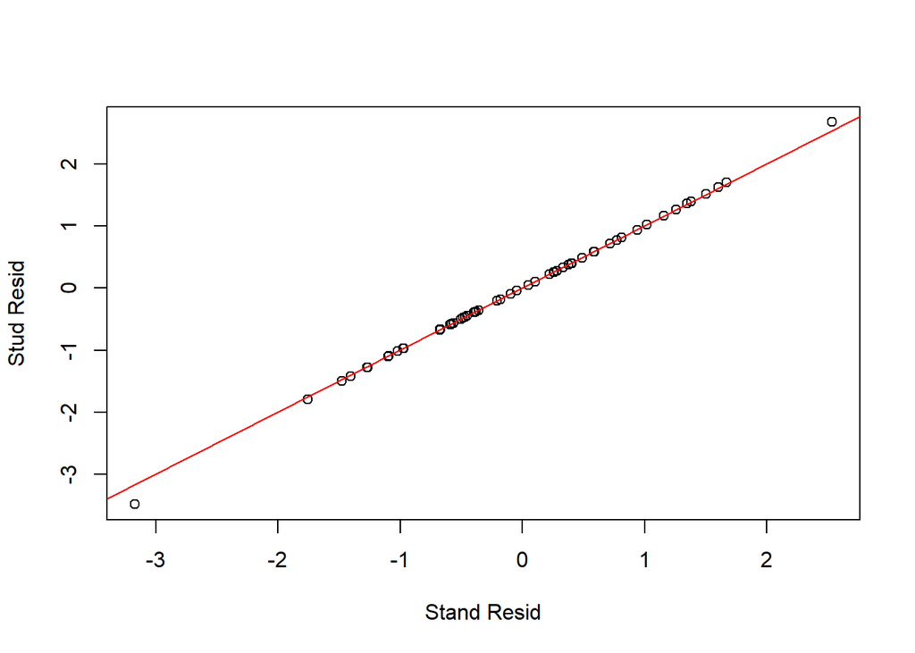

```r
plot(rstandard(lm.fin.dirty), studres(lm.fin.dirty), ylab = "Stud Resid", xlab = "Stand Resid")
abline(line(studres(lm.fin.dirty) ~ rstandard(lm.fin.dirty))$coefficients, col = "red")
```

В нашем случае выявить выбросы по этому графику затруднительно.

### Стьюдентизированные остатки vs рычаги

По горизонтальной оси отложены значения рычагов индивидов (переходит в расстояние Махаланобиса), по вертикальной — стьюдентизированные остатки (переходит в расстояние Кука).

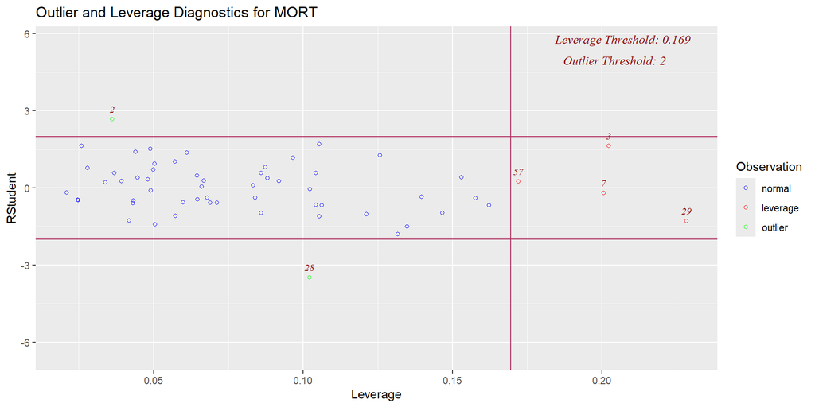

```r
ols_plot_resid_lev(lm.fin.dirty, threshold = 2)
```

### Посмотрим на выбросы на матричном графике

```r
df.dirty |>
  select(NOX, PREC, EDUC, NONW, MORT) |>
  scatterPlotMatrix(corrPlotType = "Text",
                    regressionType = 0,
                    plotProperties = list(noCatColor = "Indigo"),
                    height = 820, width = 860)
```

[interactive chart not shown]

Точка 32 выделяется во всех графиках с *PREC*, что подтверждает, что это выброс. Будем считать за выбросы точки 28 и 32.

### Удаление выбросов из модели

```r
outliers.new <- c(28, 32)
df.fin <- df.dirty[-outliers.new,]
lm.fin.fin <- lm.beta(lm(MORT ~ NOX + EDUC + NONW + PREC, data = df.fin))
summary(lm.fin.fin)
```

```
##
## Call:
## lm(formula = MORT ~ NOX + EDUC + NONW + PREC, data = df.fin)
##
## Residuals:
##     Min      1Q  Median      3Q     Max
## -69.720 -20.382  -2.115  20.259  82.153
##
## Coefficients:
##             Estimate Standardized Std. Error t value Pr(>|t|)
## (Intercept) 955.4226           NA    82.8584  11.531 4.58e-16 ***
## NOX          18.7153       0.3567     4.1135   4.550 3.17e-05 ***
## EDUC        -20.2664      -0.2771     6.0996  -3.323 0.001621 **
## NONW         21.9293       0.3122     5.3285   4.115 0.000136 ***
## PREC          3.2190       0.5098     0.5863   5.490 1.16e-06 ***
## ---
## Signif. codes:  0 '***' 0.001 '**' 0.01 '*' 0.05 '.' 0.1 ' ' 1
##
## Residual standard error: 31.83 on 53 degrees of freedom
## Multiple R-squared:  0.7471, Adjusted R-squared:  0.728
## F-statistic: 39.14 on 4 and 53 DF,  p-value: 3.135e-15
```

$R^2_{adj}$ вырос (до удаления выбросов он был 0.68), все коэффициенты модели значимы.

## Предсказания

Предскажем значение смертности в городах, которые были выкинуты как выбросы.

```r
# NOX.values <- c(small = 0.8, med = 2, large = 5)
# PREC.values <- c(small = 15, med = 35, large = 55)
# EDUC.values <- c(small = 9, med = 11, large = 13)
# NONW.values <- c(small = 0, med = 2, large = 3.5)
# vals.to.predict <- data.frame(expand.grid(NOX = NOX.values, PREC = PREC.values,
#                                           EDUC = EDUC.values, NONW = NONW.values))
vals.to.predict <- data.frame(df.dirty[outliers.new,]) |> select(NOX, PREC, EDUC, NONW)
pred <- cbind(predict(lm.fin.fin, vals.to.predict, interval = "confidence"),
              predict(lm.fin.fin, vals.to.predict, interval = "prediction")[,-1])
colnames(pred) <- c("Fitted", "Lower conf bound", "Upper conf bound", "Lower pred bound", "Upper pred bound")
pred
```

```
##      Fitted Lower conf bound Upper conf bound Lower pred bound Upper pred bound
## 28 961.0738         939.5393         982.6083         893.7035         1028.444
## 32 972.5720         942.3391        1002.8049         901.9389         1043.205
```

Истинные значения смертности в этих городах (первое значение для 28, второе - для 32):

```r
df[outliers.new, "MORT"]
```

```
## [1] 844.053 861.439
```

В обоих случаях действительная смертность ниже, чем нижняя граница предсказательного интервала, что подтверждает то, что эти города являются выбросами по отношению к модели.